# Tree Based Methods - Examen

## DEEL 2: SUPERVISED LEARNING

NASA heeft enkele asteroïden gelabeld op basis van hun gevaarlijkheid. Je kan de kolom 'Hazardous' opnieuw toevoegen aan de data om supervised learning uit te voeren en te proberen om te voorspellen welke asterioden gevaarlijk zijn en welke niet.

### Trainen van de classifier

Splits eerst de features op in een training- en test set. **Standardiseer** de data vooraleer je een classifier traint.

Zorg ervoor dat er exact **1000 samples** in de test set steken en gebruik een **random_state = 0**.

```python
from sklearn.model_selection import train_test_split

# Opsplitsen in features en targets.
X=df_reduced.drop("Hazardous", axis=1)
y=df_reduced.Hazardous

# Opsplitsen in test en training_set met 1000 waarden in test set en random_state = 0. Standardiseer de features.

X_train, X_test, y_train, y_test = train_test_split(X, y, test_size=1000, random_state=0)

scaler = StandardScaler()
X_train_std = scaler.fit_transform(X_train)
X_test_std = scaler.transform(X_test)
```

Train nog even als benchmark snel een logistic regression classifier met een **C-waarde van 0.001**

Test deze classifier: bepaal de accuracy, precision, recall en f1-score. Geef ook de confusion matrix.

```python
from sklearn.linear_model import LogisticRegression

# Trainen en testen van een logistic regression classifier met C=0.001
logreg = LogisticRegression(C=0.001)

# Training van het model
logreg.fit(X_train_std, y_train)

# Testen van het model op de test set en tonen van accuracy, confusion matrix en classification report.
# voorspellingen - klasses
y_pred = logreg.predict(X_test_std)
```

```
              precision    recall  f1-score   support

         0.0       0.85      1.00      0.92       846
         1.0       1.00      0.02      0.04       154

    accuracy                           0.85      1000
   macro avg       0.92      0.51      0.48      1000
weighted avg       0.87      0.85      0.78      1000
```

```
<sklearn.metrics._plot.confusion_matrix.ConfusionMatrixDisplay at 0x1235a526990>
```

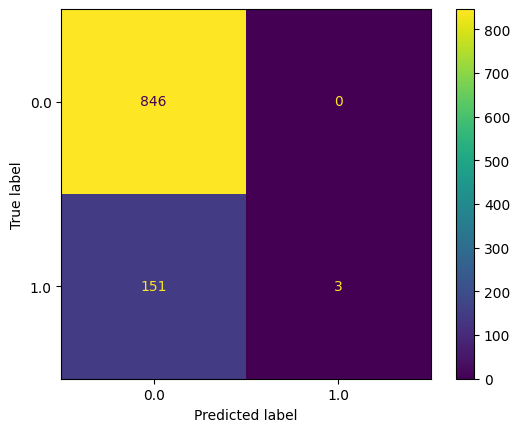

```python
from sklearn.metrics import accuracy_score,confusion_matrix,classification_report, ConfusionMatrixDisplay

print(classification_report(y_test, y_pred))
cm = confusion_matrix(y_test, y_pred, labels=logreg.classes_)
disp = ConfusionMatrixDisplay(confusion_matrix=cm, display_labels=logreg.classes_)
disp.plot()
```

### Bespreek de bekomen testresultaten van de logistic regression classifier met C=0.001.

**Bespreek de getallen in de confusion matrix**. Zijn deze te linken aan de al dan niet gebalanceerdheid van de data?

Het optimaliseren van de prestaties voor klasse 1, mogelijk door resampling technieken of door het aanpassen van de classificatiedrempel, kan helpen om een evenwichtiger model te verkrijgen.

### Gebruik **5-fold cross-validatie [met GridSearchCV] om een goede C-waarde te vinden voor de logistic regression classifier**

Zorg ervoor dat je meer gewicht geeft aan de minderheidsklasse met de parameter 'class-weight'. Zoek de beste C tussen 0.001, 0.01, 0.1, 1, 10, 100, 1000,10000 en 100000.

```python
# Cross-validatie logistic regression
# Grid search logistic regression
from sklearn.model_selection import GridSearchCV

log_model = LogisticRegression(class_weight='balanced')
param_grid = {"C": [0.001, 0.01, 0.1, 1, 10, 100, 1000,10000, 100000]}
grid_model = GridSearchCV(log_model,param_grid=param_grid) # default is 5 cv
grid_model.fit(X_train_std, y_train)
grid_model.best_params_
```

```
{'C': 1000}
```

```
              precision    recall  f1-score   support

         0.0       0.99      0.94      0.97       846
         1.0       0.75      0.95      0.84       154

    accuracy                           0.94      1000
   macro avg       0.87      0.95      0.90      1000
weighted avg       0.95      0.94      0.95      1000
```

```
<sklearn.metrics._plot.confusion_matrix.ConfusionMatrixDisplay at 0x1235c63c550>
```

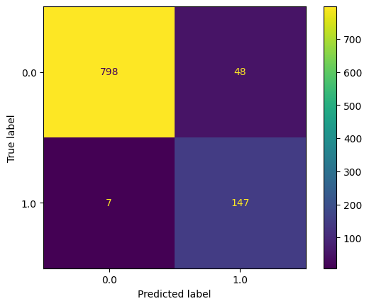

```python
y_pred_grid = grid_model.predict(X_test_std)
print(classification_report(y_test, y_pred_grid))
cm = confusion_matrix(y_test, y_pred_grid, labels=grid_model.classes_)
disp = ConfusionMatrixDisplay(confusion_matrix=cm, display_labels=grid_model.classes_)
disp.plot()
```

### Wat zijn de bevindingen na cross-validatie?**

Welke C geeft het beste resultaat? Is het resultaat beter of slechter? Verklaar!

**Antwoord:** beste C is 1000. Het is veel beter: van 151 misclassified en 3 correct met C=0.001 zijn we met C=1000 slechts 7 misclassified. Voor de eerste klasse iets minder accuraat, maar overal beter.

- C = 0.001:
- f1-score = 0.92 voor 0 en = 0.04 voor 1
- accuracy = 0.85
- C = 1000
- f1-score = 0.97 voor 0 en = 0.84 voor 1
- accuracy = 0.94

Dus een meer complexe model heeft beter predicties

### Train nu een **Random Forest Classifier**.

Het max_number_of_features is een hyperparameter waarvan je zelf de optimale waarde zoekt (veelvouden van 2 tot max aantal features). Gebruik de instelling van 200-tal bomen. Doe de hyperparameter tuning [opnieuw met GridSearchCV] voor het optimaal aantal max_number_of_features [in stappen van 2, de code staat hiervoor klaar].

- Test deze classifier op de trainingset. Wat zijn jouw bevindingen en conclusies? Vergelijk de resultaten met deze van logistic regression.
- Bepaal via deze random forest tree classifier de belangrijkste features.

```python
df.shape
```

```
(4687, 32)
```

```python
# Trainen en testen van een random forest tree classifier
from sklearn.ensemble import RandomForestClassifier

# Startpunt
number_of_trees = 200

# Hyperparametertuning: zoek enkel max_features (veelvouden van 2 tot max)
n_features = 32

step = 2
if n_features < step:
    max_features_grid = [n_features]
else:
    max_features_grid = list(range(step, n_features + 1, step))
    if max_features_grid[-1] != n_features:
        max_features_grid.append(n_features)


print("Max features grid:", max_features_grid)
```

```
Max features grid: [2, 4, 6, 8, 10, 12, 14, 16, 18, 20, 22, 24, 26, 28, 30, 32]
```

```python
rf_base = RandomForestClassifier(random_state=0, n_estimators=number_of_trees)
param_grid = {"max_features": max_features_grid}
grid_search_rf = GridSearchCV(
    estimator=rf_base,
    param_grid=param_grid,
    scoring="accuracy",
    cv=5,
    n_jobs=-1,
)

grid_search_rf.fit(X_train, y_train) # geen nood aan scaled data
print("Best CV accuracy:", grid_search_rf.best_score_)
print("Best max_features:", grid_search_rf.best_params_)
```

```
Best CV accuracy: 0.9967453935054955
Best max_features: {'max_features': 12}
```

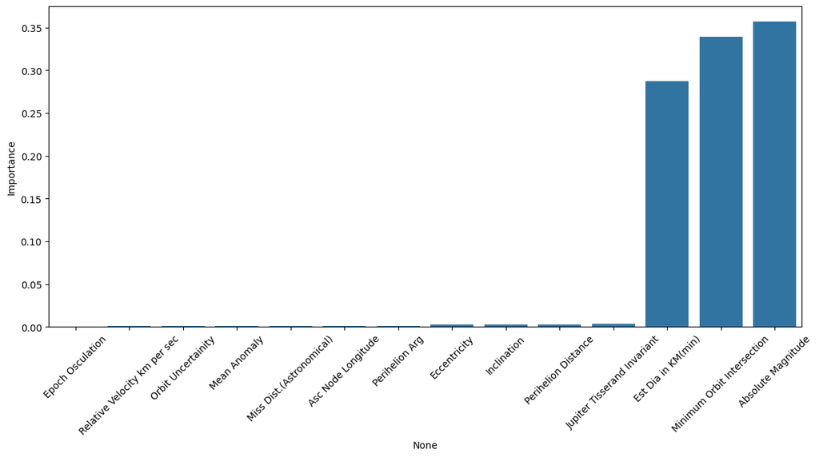

```python
# Beste model (GridSearchCV refit standaard op volledige trainset)
RFCmodel = grid_search_rf.best_estimator_

# Feature importances met variabelenamen (gesorteerd)
importances = pd.Series(RFCmodel.feature_importances_, index=X.columns).sort_values(ascending=False)

# Toon de belangrijkste features in een figuur
feats = pd.DataFrame(index=X.columns, data=RFCmodel.feature_importances_,columns=['Importance'])
imp_feats = feats[feats['Importance']>0].sort_values("Importance")

plt.figure(figsize=(14,6))
sns.barplot(data=imp_feats.sort_values('Importance'),x=imp_feats.sort_values('Importance').index,y='Importance')
plt.xticks(rotation=45)
plt.show()
```

```
              precision    recall  f1-score   support

         0.0       0.99      1.00      1.00       846
         1.0       1.00      0.97      0.98       154

    accuracy                           0.99      1000
   macro avg       1.00      0.98      0.99      1000
weighted avg       1.00      0.99      0.99      1000
```

```
<sklearn.metrics._plot.confusion_matrix.ConfusionMatrixDisplay at 0x1234e13cd60>
```

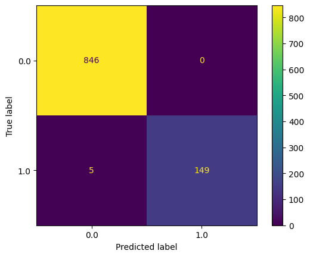

```python
# Test Random Forest Classifier
y_pred_rfc = RFCmodel.predict(X_test)
# Toon opnieuw accuracy, confusion matrix en classification report voor het beste model van de random forest classifier.
print(classification_report(y_test, y_pred_rfc))
cm = confusion_matrix(y_test, y_pred_rfc, labels=RFCmodel.classes_)
disp = ConfusionMatrixDisplay(confusion_matrix=cm, display_labels=RFCmodel.classes_)
disp.plot()
```

**Welke zijn de 5 belangrijkste features van de getrainde Random Forest Classifier?** ik zie er drie vooral: zie de uiterst rechtste bars van het barplot hierboven (dat was trouwens al uit de corr matrix duidelijk helemaal in het begin)

**Is dit resultaat beter dan Logistic Regression? Waarom wel/niet?** Veel beter, omdat dit een ensemble learning is die geavanceerde techniek tov simple logreg is (met veel modellen parallel aan het werk en bootstrapping van de data)

## Voor extra punten (indien je nog tijd hebt):

Daarstraks heb je met een kmeans clustering model verschillende clusters gemaakt. Komen deze clusters overeen met het al dan niet gevaarlijk zijn van een asteriode? Doe hiervoor een beperkte analyse. Wat kan je concluderen?

```python
# spijtig, geen tijd :(((
```